# Ekspresowa analiza ryzyka:

Helicoverpa zea* (Boddie, 1850)

Wojciech Kubasik<sup>A</sup>, Magdalena Gawlak<sup>A</sup>, Michał Czyż<sup>A</sup>, Agata Olejniczak<sup>A</sup>, Tomasz Kałuski<sup>A</sup>

A Instytut Ochrony Roślin, ul. Węgorka 20, Poznań, 60-318

Autor korespondencyjny: plantquarantine@pra.org

*Październik 11, 2017[^1]*

# Podsumowanie

Podsumowanie Analizy Ryzyka Zagrożenia Agrofagiem (Ekspres PRA) dla *Helicoverpa zea*

**Obszar PRA:** Rzeczpospolita Polska

**Opis obszaru zagrożenia:** uprawy polowe (głównie kukurydzy), przede wszystkim w Polsce północno-zachodniej, w niewielkim stopniu również uprawy w warunkach chronionych w całej Polsce.

**Ogólna ocena ryzyka:** Średnie

Ryzyko fitosanitarne

Średnie

Poziom niepewności oceny

Średnia

**Inne rekomendacje:**

- Należy na bieżąco sprawdzać informacje o znaczących stratach wyrządzanych przez *H. armigera* i na podstawie odłowionych osobników dorosłych sprawdzać, czy nie są to przedstawiciele *H. zea*.

# I Wstęp

**Powód wykonania PRA:** *Helicoverpa zea* jest gatunkiem rozprzestrzenionym w strefach tropikalnych, subtropikalnych i umiarkowanych obu Ameryk. Gąsienica żeruje polifagicznie na wielu gatunkach roślin, zarówno dzikich, jak i uprawnych. W Ameryce Północnej powoduje ona znaczne straty w uprawie, między innymi kukurydzy i soi. Ponieważ motyle potrafią migrować na znaczne odległości, gąsienice są spotykane również w regionach, gdzie gatunek ten nie jest w stanie przezimować. Istnieje ryzyko zawleczenia tego gatunku do Europy, gdzie będzie mógł się dalej rozprzestrzeniać samoistnie.

**Obszar PRA:** Rzeczpospolita Polska

# II Ocena zagrożenia Agrofagiem

1. Taksonomia:
- Królestwo: Animalia
- Typ: Arthropoda
- Podtyp: Hexapoda
- Gromada: Insecta
- Rząd: Lepidoptera
- Rodzina: Noctuidae
- Rodzaj: *Helicoverpa*
- Gatunek: *Helicoverpa zea* (Boddie, 1850)*

Na podstawie: EPPO (2018)

**Synonimy:** *Heliothis zea* (Boddie, 1850), *Phalaena zea* (Boddie, 1850), *Bombyx obsoleta* Fabricius 1775, *Heliothis umbrosa* Grote

**Nazwa powszechna:** American bollworm, corn earworm, tomato fruitworm, New World bollworm (angielska), Chenille des épis du maïs (francuska), Amerikanischer Baumwollkapselwurm (niemiecka)

2. Informacje ogólne o agrofagu:

*Helicoverpa zea* jest gatunkiem rozpowszechnionym na obu kontynentach amerykańskich, o dużych skłonnościach migracyjnych. Szczegółowe informacje o tym gatunku dostępne są na stronach (EPPO (2018), CABI/EPPO (2017)) oraz stronach CABI (2018). Dużo informacji o biologii i szkodliwości można znaleźć także na stronach University of Florida Capinera (2000).

Gąsienice żerują polifagicznie na wielu gatunkach roślin z różnych rodzin, jednak największe straty ekonomiczne przynoszą szkody wyrządzane w uprawach kukurydzy. Larwy mogą żerować na większości organów nadziemnych roślin, zjadając i dziurawiąc liście jak, i wgryzając się do wnętrza pędów, owoców oraz kolb kukurydzy. Gatunek ten najłatwiej wykryć w stadium gąsienicy, są one jednak dość zmiennie ubarwione i istnieje możliwość pomyłki z innymi przedstawicielami rodziny sówkowatych (Noctuidae). Typowo ubarwiona gąsienica ma ciemny grzbiet ciała (zwykle brązowy) z czarnymi pinaculami, jaśniejszy pasek po bokach ciała i jasny spód ciała (barwy od cielistej, przez żółtą do zielonej). Szczegóły budowę larw można znaleźć w kluczu, który opracował Passoa (2014), Lepintercept (2017).

Ponieważ gąsienice zazwyczaj wgryzają się do wnętrza organów roślin to by je znaleźć trzeba często rozciąć pęd czy kolbę kukurydzy. Na podstawie gąsienicy jest bardzo trudno stwierdzić czy mamy do czynienie z *H. zea*, czy też z występującą w Polsce *H. armigera*. Gąsienice należy zebrać i wyhodować postaci dorosłe, których identyfikacja jest możliwa na podstawie budowy aparatów kopulacyjnych. Osobniki dorosłe mogą być także odławiane do pułapek świetlnych i feromonowych Capinera (2000).

3. Czy agrofag jest wektorem?

**Nie**

4. Czy do wejścia lub rozprzestrzenienia agrofaga potrzebny jest wektor.

**Nie**

5. Status regulacji agrofaga:

| Kontynent/Region | Kraj/RPPP | Status | Rok |
| --- | --- | --- | --- |
| Afryka | Afryka Wschodnia | lista A1 | 2001 |
|  | Afryka Południowa | lista A1 | 2001 |
| Azja | Bahrain | lista A1 | 2003 |
|  | Izrael | Szkodnik kwarantannowy | 2009 |
| Europa | Turcja | lista A1 | 2007 |
| RPPO/EU | APPPC | lista A1 | 1988 |
|  | EPPO | lista A1 | 1994 |
|  | EU | Aneks I/A1 | 1992 |
|  | PPPO | lista A1 | 1993 |

6. Rozmieszczenie:

[output not shown]

7. Rośliny żywicielskie i ich rozmieszczenie na obszarze PRA:

| Nazwa naukowa szkodnika (nazwa powszechna) | Obecność na obszarze PRA | Komentarze | Źródła |
| --- | --- | --- | --- |
| *Abelmoschus esculentus* (piżmian jadalny, okra) | Nie | Gatunek uprawny w krajach o klimacie tropikalnym i subtropikalnym. | CABI (2018) |
| *Abutilon theophrasti* (zaślaz pospolity) | Tak | Pochodzący z Azji wschodniej gatunek lokalnie zadomowiony na obszarze PRA. | CABI (2018) |
| *Amaranthus* (szarłat) | Tak | Na obszarze PRA gatunki dziko rosnące (w tym pospolicie występujące w uprawach chwasty) oraz rośliny ozdobne. | CABI (2018) |
| *Arachis hypogaea* (orzacha podziemna, orzech ziemny) | Nie | Jednoroczna roślina uprawna pochodząca z Ameryki. Do Polski sprowadzane są owoce do celów spożywczych. We florze Polski notowana jako efemerofit. | CABI (2018) |
| *Brassica oleracea* (kapusta warzywna) | Tak | Roślina uprawna na całym obszarze PRA. | CABI (2018) |
| *Brassica oleracea* var. *botrytis* (kalafior) | Tak | Roślina uprawna na całym obszarze PRA. | CABI (2018) |
| *Brassica oleracea* var. *capitata* (kapusta głowiasta) | Tak | Roślina uprawna na całym obszarze PRA. | CABI (2018) |
| *Cajanus cajan* (nikla indyjska) | Nie | Gatunek uprawny w krajach o klimacie tropikalnym. | CABI (2018) |
| *Capsicum* (papryka) | Tak | Na obszarze PRA C.annuum jest rośliną uprawianą. Dostępne są odmiany ozdobne uprawiane w warunkach domowych. | CABI (2018) |
| *Capsicum annuum* (papryka roczna) | Tak | Na obszarze PRA C. annuum jest rośliną uprawianą. W cieplejszych rejonach kraju możliwa uprawa w gruncie, jednak częściej pod osłonami. Dostępne są odmiany ozdobne uprawiane w doniczkach w warunkach d… | CABI (2018) |
| *Chenopodium quinoa* (komosa ryżowa) | Tak | Na obszarze PRA roślina rzadko uprawiana, efemerofit. | CABI (2018) |
| *Cicer arietinum* (ciecierzyca pospolita) | Tak | Na obszarze PRA roślina uprawiana głównie pod osłonami, efemerofit. | CABI (2018) |
| *Citrus* (cytrusy) | Tak | Rośliny uprawne. Na obszarze PRA niektóre gatunki uprawiane jako ozdobne w warunkach domowych, w szklarniach i oranżeriach. Owoce sprowadzane do celów spożywczych i przetwórstwa. | CABI (2018) |
| *Cucumis melo* (ogórek melon) | Tak | Roślina uprawna na obszarze PRA w gruncie i pod osłonami. Uprawy poboczne, uprawy amatorskie. | CABI (2018) |
| *Cucumis sativus* (ogórek siewny) | Tak | Roślina uprawna na całym obszarze PRA. | CABI (2018) |
| *Fragaria* (poziomka) | Tak | Rośliny uprawiane i dziko rosnace na całym obszarze PRA. | CABI (2018) |
| *Fragaria* x *ananassa* (truskawka, poziomka ananasowa) | Tak | Roślina uprawna na całym obszarze PRA w gruncie i pod osłonami. | CABI (2018) |
| *Geranium carolinianum* (Carolina geranium) | Nie |  | CABI (2018) |
| *Gerbera* (gerbera) | Tak | Roślina uprawiana na obszarze PRA w warunkach szklarniowych i domowych jako roślina ozdobna. Wrażliwa na mrozy, w Polsce nie przetrzymuje zimy. | CABI (2018) |
| *Glycine max* (soja warzywna, soja zwyczajna) | Tak | Roślina uprawna na obszarze PRA. Gatunek przejściowo dziczejący. | CABI (2018) |
| *Gossypium* (bawełna) | Nie | Ważna roślina uprawna nie występująca na obszarze PRA. | CABI (2018) |
| *Helianthus annuus* (słonecznik zwyczajny) | Tak | Roślina uprawna na obszarze PRA. Także jako roślina ozdobna. | CABI (2018) |
| *Ipomoea purpurea* (wilec purprowy) | Tak | Na obszarze PRA gatunek uprawiany jako roślina ozdobna i przejściowo dziczejąca (efemerofit). | CABI (2018) |
| *Lactuca sativa* (sałata siewna) | Tak | Roślina uprawna na obszarze PRA. | CABI (2018) |
| *Lamium amplexicaule* (jasnota różowa) | Tak | Pospolita roślina dziko rosnąca na całym obszarze PRA. Roślina ruderalna, także w uprawach rolniczych jako chwast. | CABI (2018) |
| *Lespedeza juncea* var. *sericea* | Nie |  | CABI (2018) |
| *Lonicera japonica* (wiciokrzew japoński) | Tak | Roślina uprawiana w ogrodach jako ozdobna. | CABI (2018) |
| *Medicago lupulina* (lucerana nerkowata) | Tak | Pospolita roślina dziko rosnąca na całym obszarze PRA. | CABI (2018) |
| *Medicago sativa* (lucerna siewna) | Tak | Roślina uprawna i dziczejąca na całym obszarze PRA. | CABI (2018) |
| *Nicotiana tabacum* (tytoń szlachetny) | Tak | Roślina uprawna i przejściowo dziczejąca na obszarze PRA. | CABI (2018) |
| *Panicum miliaceum* (proso zwyczajne) | Tak | Gatunek rzadko uprawiany na obszarze PRA, przejściowo dziczejący. | CABI (2018) |
| *Phaseolus* (fasola) | Tak | Rośliny uprawiane na obszarze PRA. | CABI (2018) |
| *Phaseolus vulgaris* (fasola zwyczajna) | Tak | Roślina uprawna na całym obszarze PRA. | CABI (2018) |
| *Salix* (wierzby) | Tak | Wiele gatunków dziko rosnących i uprawianych jako rośliny ozdobne. | CABI (2018) |
| *Securigera varia* (cieciorka pstra) | Tak | Stosunkowo pospolita roślina dziko rosnąca na całym obszarze PRA. | CABI (2018) |
| *Solanum lycopersicum* (pomidor) | Tak | Roślina uprawna na całym obszarze PRA, w gruncie i pod osłonami. | CABI (2018) |
| *Solanum melongena* (psianka podłużna, bakłażan) | Tak | Roślina uprawna, na obszarze PRA głównie pod osłonami. | CABI (2018) |
| *Sorghum bicolor* (sorgo dwubarwne) | Nie/tak? | Podejmowane są próby uprawy tego gatunku na obszarze PRA. | CABI (2018) |
| *Spinacia oleracea* (szpinak warzywny) | Tak | Roślina uprawna na całym obszarze PRA, w gruncie i pod osłonami. | CABI (2018) |
| *Trifolium* (koniczyny) | Tak | Wiele gatunków dziko rosnących i uprawianych jako rośliny pastewne oraz w płodozmianie. | CABI (2018) |
| *Trifolium incarnatum* (koniczyna krwistoczerwona) | Tak | Gatunek uprawiany na obszarze PRA. | CABI (2018) |
| *Vivia sativa* (wyka siewna) | Tak | Roślina dziko rosnąca i uprawna (pastewna) na całym obszarze PRA. | CABI (2018) |
| *Vicia villosa* (wyka kosmata) | Tak | Roślina dziko rosnąca i uprawna (pastewna) na całym obszarze PRA. | CABI (2018) |
| *Vigna unguiculata* (wspięga wężowata) | Nie |  | CABI (2018) |
| *Zea mays* (kukurydza) | Tak | Roślina uprawna na całym obszarze PRA. | CABI (2018) |
| *Zea mays* subsp. *mays* (kukurydza cukrowa) | Tak | Roślina uprawna na całym obszarze PRA. | CABI (2018) |

8. Drogi przenikania:

Najbardziej prawdopodobne jest przenikanie gatunku w stadium jaja, gąsienicy lub poczwarki. Mogą być one zawlekane z:

- roślinami do sadzenia (z wyłączeniem nasion, bulw i cebulek) z lub bez podłoża
- częściami roślin i produktami roślinnym, takimi jak:
  - kwiaty cięte i gałęzie,
  - cięte drzewa,
  - owoce i warzywa.

W wypadku rozwinięcia się na terenie Europy osiadłej populacji H. zea, gatunek ten będzie mógł się rozprzestrzeniać dalej drogą naturalnej migracji. Istnieje także możliwość przedostania się osobników dorosłych z transportem lotniczym, zwłaszcza z terenów, gdzie gatunek ten występuje w dużej liczebności (np. Ameryka Środkowa).

| Możliwa droga przenikania | Droga przenikania: |
| --- | --- |
| Krótki opis, dlaczego jest rozważana jako droga przenikania | *H. zea* jest polifagiem i istnieje teoretycznie możliwość przedostania się form preimaignalnych (jaja, larwy, poczwarki) z roślinami importowanymi z Ameryki Południowej i Północnej. |
| Czy droga przenikania jest zakazana na obszarze PRA? | Nie |
| Czy agrofag był już przechwycony tą drogą przenikania? | Nie |
| Jakie stadium jest najbardziej prawdopodobnie związane z tą drogą przenikania? | jaja, larwy, poczwarki |
| Jakie są ważne czynniki związane z tą drogą przenikania? | Transport żywych roślin w możliwie krótkim czasie |
| Czy agrofag może przeżyć transport i składowanie w tej drodze przenikania? | Tak |
| Czy agrofag może zostać przeniesiony z tej drogi przenikania na odpowiednie siedlisko? | Tak |
| Czy wielkość przemieszczania tą drogą przenikania sprzyja wejściu agrofaga? | Tak |
| Czy częstotliwość przemieszczania tą drogą przenikania sprzyja wejściu agrofaga? | Tak |
| Ocena prawdopodobieństwa wejścia | Średnie |
| Ocena niepewności | Wysoka |

[output not shown]

[output not shown]

9. Prawdopodobieństwo zasiedlenia w warunkach zewnętrznych (środowisko naturalne i zarządzane oraz uprawy) na obszarze PRA:

W obecnych warunkach klimatycznych nie ma możliwości rozwinięcia się stałych populacji *H. zea* w Polsce. Ponieważ jest to gatunek migrujący, w wypadku powstania licznych populacji w Europie Południowej, istnieje możliwość czasowej kolonizacji i wyrządzania szkód przez gąsienice, jak ma to miejsce w północnych stanach USA i południowej Kanadzie. Blisko spokrewniony z *H. zea* gatunek – *H. armigera*, jest już notowany w Polsce jako szkodnik kukurydzy, jednak pojawiający się niezbyt licznie i bez większego znaczenia ekonomicznego.

Model niszy klimatycznej agrofaga został opracowny w programie CLIMEX 4.0 Commonwealth Scientific and Industrial Research Organisation (CSIRO) (2004). Ze względu na słabą dostępność danych wymaganych do modelowania wykorzystano parametry niszy klimatycznej blisko spokrewnionego gatunku *H. amigera* Zalucki i Furlong (2015), które następnie korygowano o informacje dotyczące diapauzy i wymagań temperaturowych Olmstead i in. (2016). W kolejnym etapie modelowania dopasowywano poszczególne parametry wilgotności oraz temperatury inicjującej i terminującej diapauzę, tak aby wynik odzwierciedlał rozmieszczenie owada na terenie Ameryki Północnej (Załącznik 1 Tab 4). Ze względu na obecność agrofaga na obszarze Kalifornii modelowanie przeprowadzano z założeniem irygacji 3,6 mm/dzień (25 mm/tydzień, patrz Mika i Newman (2010)). Modelowanie przeprowadzono na danych historycznych z okresu referencyjnego 1961-1990. Następnie użyto zunifikowanych danych z okresu 1986-2015 jako zmiany klimatycznej w stosunku do okresu referencyjnego do określenia bieżących warunków klimatycznych panujących na obszarze PRA.

| Ocena | Niskie | Średnie | Wysokie |
| --- | --- | --- | --- |
| Ocena prawdopodobieństwa zadomowienia w warunkach zewnętrznych | X | . | . |
| Ocena niepewności | . | X | . |

10. Prawdopodobieństwo zasiedlenia w uprawach pod osłonami na obszarze PRA:

Jako polifag *H. zea* może rozwijać się na wielu roślinach, w tym uprawianych w szklarniach roślinach ozdobnych i warzywach. Dla spokrewnionego gatunku, *H. armigera*, notowano w Europie liczne wystąpienia w warunkach upraw chronionych ([PRA Helicoverpa amigera](https://secure.fera.defra.gov.uk/phiw/riskRegister/downloadExternalPra.cfm?id=3879)). Ponieważ w warunkach upraw pod osłonami gatunek ten jest dość łatwy do wykrycia i zwalczenia (duże gąsienice), a prawdopodobieństwo przenoszenia jest niewielkie, nie należy spodziewać się rozwinięcia populacji utrzymujących się przez dłuższy czas.

| Ocena | Niskie | Średnie | Wysokie |
| --- | --- | --- | --- |
| Ocena prawdopodobieństwa zasiedlenia w uprawach chronionych | X | . | . |
| Ocena niepewności | . | X | . |

11. Rozprzestrzenienie na obszarze PRA:

Motyle H. zea mają duże zdolności dyspersyjne i mogą pokonywać dystans przekraczający kilkaset kilometrów. W takim wypadku rozprzestrzenianie z udziałem człowieka ma znaczenie marginalne. Gatunek ten posiada ogromne możliwości dyspersyjne. Duże populacje motyli potrafią migrować na wysokości nawet 900 m. n. p. m. na odległości przekraczające 400 km. Dlatego, mimo że aktualnie warunki pogodowe na terenie PRA raczej nie są korzystne do zasiedlenia możliwe są naloty owada z pobliskich krajów, w których warunki sprzyjają zasiedleniu (np. z Węgier). Taka sytuacja ma miejsce w natywnym zasięgu na terenie USA, gdzie uważa się, że osobniki znajdywane na północy (powyżej 40 równoleżnika) nie tworzą stałych populacji, i prawdopodobnie na zimę migrują na południe (patrz przegląd literatury w Olmstead i in. (2016)).

| Ocena | Niskie | Średnie | Wysokie |
| --- | --- | --- | --- |
| Ocena wielkości rozprzestrzenienia na obszarze PRA | X | . | . |
| Ocena niepewności | X | . | . |

12. Wpływ na obcecnym obszarze zasięgu:
1. Wpływ na bioróżnorodność

Na obszarach, gdzie *H. zea* występuje licznie, może być ona istotnym elementem sieci troficznych. Dorosłe osobniki mogą stanowić ważny element diety niektórych gatunków ptaków, nietoperzy. Stadia preimaginalne mogą być zjadane przez drapieżne owady oraz owadożerne ssaki. Są one także ważnym miejscem rozwoju parazytoidów. Pełną listę naturalnych wrogów *H. zea* podaje Kogan i in. (1989).

| Ocena | Niskie | Średnie | Wysokie |
| --- | --- | --- | --- |
| Ocena wielkości wpływu na bioróżnorodność na obecnym obszarze zasięgu | . | X | . |
| Ocena niepewności | . | X | . |

2. Wpływ na usługi ekosystemowe

Na obecnym obszarze występowania *H. zea* jest jednym z najistotniejszych szkodników kukurydz oraz drugim co do istotności ekonomicznej szkodnikiem w ogóle CABI (2018). Znaczne straty wyrządzane są także w uprawie bawełny, sorgo, pomidorów i wielu innych roślin.

| Usługi ekosystemowe | Czy szkodnik wpływa na tą usługę ekosystemową? | Krótki opis wpływu | Źródła |
| --- | --- | --- | --- |
| Zabezpieczająca | Tak | *H. zea* jest jednym z najistotniejszych szkodników kukurydzy w Ameryce Północnej i Południowej, mogącym rozwijać się także na wielu innych gatunkach roślin uprawnych. | Kogan i in. (1989) |
| Regulacyjna | Nie |  |  |
| Wspomagająca | Nie |  |  |
| Kulturowa | Nie |  |  |

| Ocena | Niski | Średni | Wysoki |
| --- | --- | --- | --- |
| Ocena wielkości wpływu na usługi ekosystemowe na obecnym obszarze zasięgu | . | . | X |
| Ocena niepewności | X | . | . |

3. Wpływ socjo-ekonomiczny

Szacunkowe straty powodowane przez *H. zea* (razem z *H. virescens*) na terenie USA szacowane są na 1000 milionów USD rocznie. Koszty ochrony chemicznej upraw to dodatkowo ok. 250 mln USD rocznie CABI (2018).

| Rating | Niski | Średni | Wysoki |
| --- | --- | --- | --- |
| Ocena wielkości wpływu socjoekonomicznego na obecnym obszarze zasięgu | . | . | X |
| Ocena niepewności | X | . | . |

13. Potencjalny wpływ na obszarze PRA:

Czy wpływ będzie równie duży, co na obecnym obszarze występowania? *Nie*

Ze względu na uwarunkowania klimatyczne *H. zea* nie jest w stanie wytworzyć na terenie naszego kraju osiadłych populacji. Ponieważ jest to gatunek migrujący, w wypadku powstania dużych populacji w południowej Europie istnieje możliwość, że migrujące osobniki będą licznie docierać na terytorium Polski i ze składanych jaj rozwiną się gąsienice, które lokalnie będą mogły wyrządzać znaczne szkody, zwłaszcza w uprawach kukurydzy.

1. Potencjalny wpływ na bioróżnorodność na obszarze PRA

Małe prawdopodobieństwo powstanie osiadłych populacji *H. zea* na terenie PRA. Dodatkowo nisza ekologiczna jest już tutaj zajęta przez bliźniaczy gatunek – *H. armigera*.

**Jeżeli Nie,**

| Ocena | Niski | Średni | Wysoki |
| --- | --- | --- | --- |
| Ocena wielkości wpływu na bioróżnorodność na potencjalnym obszarze zasiedlenia | X | . | . |
| Ocena niepewności | X | . | . |

2. Potencjalny wpływ na usługi ekosystemowe na obszarze PRA

Brak. **Jeżeli Nie,**

| Ocena | Niski | Średni | Wysoki |
| --- | --- | --- | --- |
| Ocena wielkości wpływu na usługi ekosystemowe na potencjalnym obszarze zasiedlenia | X | X | . |
| Ocena niepewności | . | . | . |

3. Potencjalny wpływ socjoekonomiczny na obszarze PRA

Gatunek ten może na obszarze PRA tworzyć, jako migrant, jedynie efemeryczne populacje, których liczebność może się znacznie wahać w poszczególnych latach, dlatego wpływ ten jest bardzo trudny do oszacowania. **Jeżeli Nie,**

| Ocena | Niski | Średni | Wysoki |
| --- | --- | --- | --- |
| Ocena wielkości wpływu socjoekonomiczny na potencjalnym obszarze zasiedlenia | X | . | . |
| Ocena niepewności | . | . | X |

14. Identyfikacja zagrożonego obszaru:

Obecnie zagrożone są tereny w Polsce zachodniej i północno-zachodniej oraz stosunkowo niewielkie obszary w centralnej (okolice Kutna) i wschodniej części kraju (części województw mazowieckiego i świętokrzyskiego). Potencjalnie największego wpływu można spodziewać się w zachodniej części kraju, co związane jest z klimatem, strukturą upraw (znaczny udział kukurydzy w areale zasiewów) oraz łatwością przenikania (bak istotnych barier środowiskowych i geograficznych).

15. Zmiana kliamtu:

Oprogramowanie CLIMEX umożliwia modelowanie zmiany niszy w odpowiedzi na zmianę klimatu na dwa sposoby. Pierwszym jest użycie odpowiednio sformatowanych danych klimatycznych wyliczonych na podstawie modeli klimatycznych. Drugim jest użycie zunifikowanych, globalnych wartości zmiany temperatury i opadów dla okresów letniego i zimowego, bezpośrednio w programie. Ze względu na małą dostępność danych klimatycznych, w odpowiednim dla programu CLIMEX formacie i trudności związanych z transformowaniem tego typu danych, do predykcji niszy użyto dwóch zestawów danych pochodzących z bazy CliMond – CSIRO-MK3.0 i MIROC-H. W obu przypadkach przyszły klimat oszacowany został na podstawie scenariuszy SRES: A2 i A1B dla lat 2050 i 2100 Kriticos i in. (2012). Oba scenariusze zakładają, że gospodarka światowa będzie się rozwijać z większym naciskiem na wartości ekonomiczne niż środowiskowe. Do wyznaczenia zunifikowanych wartości zmiany temperatury i opadów w okresie letnim i zimowym w okresach 2041-2070 i 2071-2100 użyto od 12 do 27 modeli w zależności od scenariusza (RCP 4.5, 6.0, 8.5) i szacowanego parametru (patrz załącznik 1). Na podstawie predykcji z każdego modelu wyznaczono średnią zmianę parametru dla obszaru PRA.

Źródła niepewności:

W przypadku użycia zagregowanych danych klimatycznych pochodzących z bazy CliMond największym źródłem niepewności jest wiarygodność wyników symulacji uwzględniającej wąski zakres możliwych projekcji rozwoju gospodarczego i związanych z nim zmian oraz możliwych okresowych wahań klimatu. Przyjęcie zagregowanych wartości z wielu globalnych modeli cyrkulacji atmosfery pozwala na przyjęcie bardziej wiarygodnej projekcji zmian klimatu, redukując tym samym zakres niepewności. Jednak użycie jednej wartości dla całego regionu powoduje niedoszacowanie lub przeszacowanie wartości parametrów w poszczególnych podregionach. Co więcej, należy zauważyć, że największe zmiany klimatu w przypadku obszaru PRA zachodzą w zimowej porze roku. Dlatego uśrednione wartości temperatury i opadu dla okresu zimowego, w skład, którego wchodzą pory roku jesienna i zimowa, obarczone są błędem. W przypadku zmian opadów niepewność predykcji jest ogólnie wysoka, co wynika z samego charakteru słabej przewidywalności tego parametru klimatu. W przypadku *H. zea* ważnym czynnikiem wpływającym na przeżycie poczwarek agrofaga jest temperatura i wilgotność podłoża. Poczwarki są w stanie przeżyć w temperaturze poniżej 0 °C , o ile wilgotność podłoża pozostaje niska. W przypadku Polski, wg szacunków, zarówno temperatura jak i opad (a zatem wilgotność podłoża) zmienią się dużo bardziej w okresie zimowym niż w jesiennym. Dlatego uśrednienie tych parametrów może niedoszacowywać stresu środowiskowego oddziałującego na agrofaga.

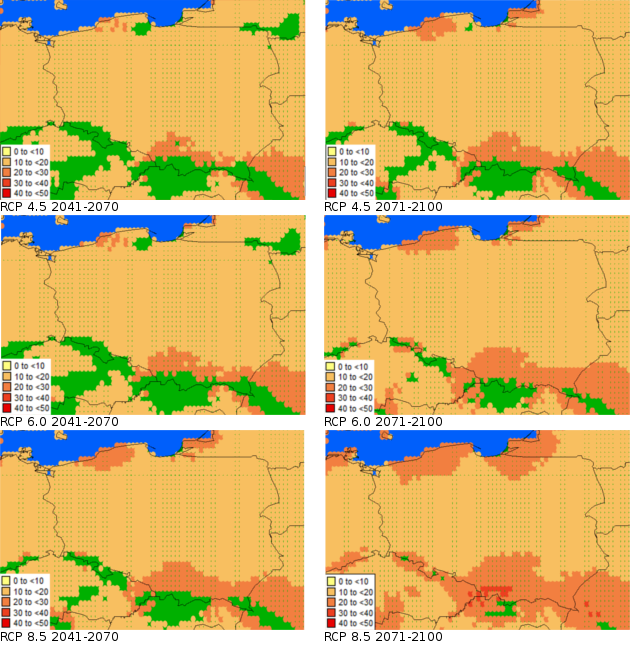

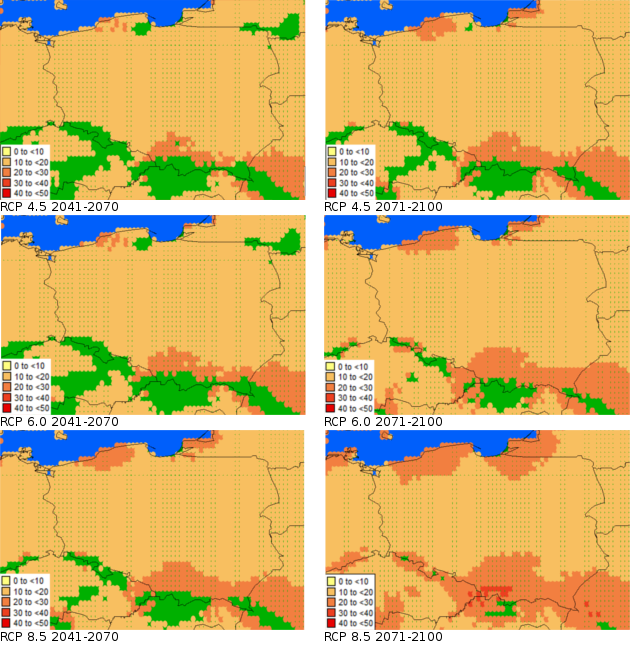

Rysunek II.2: Indeks ekoklimatyczny dla H. zea w latach 2041-2070 i 2071-2100 dla scenariuszy RCP 4.5; 6.0 i 8.5

1. Który scenariusz zmiany klimatu jest uwzględniony na lata 2050 do 2100

2. Rozważyć wpływ projektowanej zmiany klimatu na agrofaga.

Zmiany klimatyczne nie wpłyną na możliwości przenikania gatunku na obszar PRA – już w istniejących uwarunkowaniach klimatycznych jest ono teoretycznie możliwe. Mogą one jednak oddziaływać na ich częstotliwość w wypadku rozwinięcia się osiadłych populacji w pobliżu Polski (np. północne Węgry, południe Czech). Według przyjętych modeli klimatycznych w roku 2050 ponad połowa terytorium Polski będzie obszarem potencjalnego zasiedlenia przez *H. zea*, a w roku 2100 praktycznie cały obszar naszego kraju (z wyjątkiem wyższych partii gór) będzie spełniał warunki dla rozwoju tego agrofaga. Ze względu na trudność prognozowania warunków klimatycznych w okresie zimowym, nie można w tej chwili jednoznacznie ustalić, czy w rozpatrywanym okresie powstaną dogodne warunki do rozwinięcia się osiadłych populacji *H. zea*.

| Wpływ zmian klimatu na | Zmiana | Źródła |
| --- | --- | --- |
| Czy jest prawdopodobne, że drogi przenikania mogą się zmienić na skutek zmian klimatu? | Nie | EPPO (2018) |
| Czy prawdopodobieństwo zasiedlenia może się zmienić wraz ze zmianą klimatu? | Tak; prawdopodobieństwo: średnie; niepewność: średnia | Kogan i in. (1989) |
| Czy wielkość rozprzestrzenienia może się zmienić wraz ze zmianą klimatu? | Tak; prawdopodobieństwo: średnie; niepewność: średnia | EPPO (2018) |
| Czy wpływ na obszarze PRA może się zmienić wraz ze zmianą klimatu? | Tak; prawdopodobieństwo: średnie; niepewność: średnia | EPPO (2018) |

16. Ogólna ocena ryzyka:

# III Zarządzanie ryzykiem zagrożenia agrofagiem.

17. Środki fitosanitarne
1. Opisać potencjalne środki dla odpowiednich dróg przenikania i ich oczekiwaną efektywność na zapobieganie wprowadzenia (wejście i zasiedlenie) oraz/lub na rozprzestrzenienie.

| Możliwe drogi przenikania (w kolejności od najważniejszej) | Możliwe środki | Opłacalność środków |
| --- | --- | --- |
| Transport lotniczy całych roślin lub ich części. | Wykrycie w przesyłkach poprzez inspekcję przed odprawą lub trakcie transportu. | Wysoka |
| Transport lotniczy całych roślin lub ich części. | Wykrycie podczas kwarantanny po wejściu. | Średnia |
| Transport lotniczy całych roślin lub ich części. | Eradykacja z użyciem insektycydów. | Wysoka opłacalność, niskie koszty insektycydów. |

2. Środki zarządzania eradykacją, powstrzymywaniem i kontrolą

Podstawową metodą zapobiegania wniknięcia agrofaga jest wnikliwa kontrola fitosanitarna, która może odbywać się na różnych etapach transportu – od momentu przygotowywania roślin (lub ich części) po rozładunek w miejscu docelowym. Szczególnie istotne jest to w miesiącach wiosenno-letnich, kiedy to gąsienice mogłyby dokończyć swój rozwój w warunkach polowych, a jako polifag, dość łatwo znajduje rośliny pokarmowe. W wypadku wątpliwości co do zainfekowania sprowadzanego materiału, należy go poddać kwarantannie. Jeśli charakter materiału na to pozwala (np. nie są to rośliny przeznaczone do konsumpcji), powinny zostać wykonane zabiegi z użyciem środków ochrony roślin o szerokim spektrum działania (np. chloropiryfos). Można również stosować schładzanie materiału przez 2-4 dni w temperaturze 1.7°C a następnie fumigację bromkiem metylu w dawce 13.5 g/m3 przez 4 godziny. Rośliny przeznaczone do konsumpcji, których dezynsekcja jest niemożliwa, powinny zostać zniszczone, np. przez spalenie.

18. Niepewność:

Brak dostępnych informacji o przypadkach stwierdzenia na obszarze PRA przypadków odnalezienia *H. zea* w importowanym materiale roślinnym. W wypadku bardzo małych larw lub złóż jaj, możliwe jest ich przeoczenie przez służby fitosanitarne. W razie uzasadnionych podejrzeń sprowadzony materiał należy poddać kwarantannie.

19. Uwagi:

W obecnych warunkach klimatycznych środki fitosanitarne nie są konieczne w miesiącach zimowych, gdyż gatunek ten nie jest wstanie przetrwać w warunkach polowych. Nie dotyczy to jednak roślin sprowadzanych do dalszej uprawy w warunkach chronionych.

Występowanie w Europie bliźniaczego gatunku H. armigera, komplikuje nieco status *H. zea*. Rozróżnienie ich w stadium gąsienicy jest prawie niemożliwe, a identyfikacja na podstawie postaci dorosłych wymaga specjalistycznej wiedzy. Paradoksalnie występowanie *H. armigera* może utrudniać wniknięcie *H. zea*, gdyż zajmują podobne nisze ekologiczne.

# B Klimat

Modele i warunki klimatyczne.

| Czynnik klimatyczny | kod | opis | wartość |
| --- | --- | --- | --- |
| Temperatura | DV0 | temperatura limitująca dolna | 12.0000 |
|  | DV1 | temperatura optymalna dolna | 18.0000 |
|  | DV2 | temperatura optymalna gótna | 35.0000 |
|  | DV3 | temperatura limitująca górna | 42.0000 |
| Wilgotność | SM0 | wilgotność limitująca dolna | 0.0200 |
|  | SM1 | wilgotność optymalna dolna | 0.7000 |
|  | SM2 | wilgotność optymalna górna | 1.5000 |
|  | SM3 | wilgotność limitująca górna | 2.5000 |
| Diapauza | DPD0 | Długość dnia inicjująca diapuazę | 12.0000 |
|  | DPT0 | Temperatura inicjująca diapauzę | 12.0000 |
|  | DPT1 | Temperatura hamująca diapauzę | 13.0000 |
|  | DPD0 | Liczba dnia potrzebna do ukończenia diapauzy | -69.0000 |
|  | DPSW | Wskaźnik: 0 – diapauza zimowa, 1 – diapauza letnia | 0.0000 |
| Stres zimna | TTCS | temperatura progowa | 5.0000 |
|  | THCS | tempo akumulacji | -0.0003 |
| Stres cieplny | TTHS | temperatura progowa | 42.0000 |
|  | THHS | tempo akumulacji | 0.0010 |
| Stres suszy | SMDS | wilgotność progowa | 0.0200 |
|  | HDS | tempo akumulacji | -0.0050 |
| Stres wilgotności | SMWS | wilgotność progowa | 2.5000 |
|  | HWS | tempo akumulacji | 0.0050 |
| Stres zimna-wilgotności | DTCW | Minimalna liczba stopniodni powyżej DVCS | 80.0000 |
|  | MTCW | wilgotność progowa | 1.0000 |
|  | PCW | tempo akumulacji | 0.1000 |
| Akumulacja stopnio-dni powyżej DV0 | DV0 |  | 12.0000 |
|  | DV3 |  | 42.0000 |
| Akumulacja stopnio-dni powyżej DV3 | DV3 |  | 42.0000 |
|  | DV4 |  | 100.0000 |
| Akumulacja stopnio-dni powyżej DVCS | DVCS |  | 0.0000 |
|  | DV4 |  | 100.0000 |
| Stoopnio-dni na pokolenie | PDD | minimalna liczna stopnio-dni powyżej DV0 do ukończenia pokolenia | 690.0000 |

# Źródła

Billen, W., 1984. Tropische Insekten in Basel. Mitteilungen der Entomologischen Gesellschaft Basel 34, 141–144.

CABI, 2018. textitHelicoverpa zea [WWW Document]. URL https://www.cabi.org/isc/datasheet/26776 (udostępniono 9.28.18).

CABI/EPPO, 2017. EPPO quarantine pest Prepared by CABI and EPPO for the EU under Contract 90/399003 Data Sheets on Quarantine Pests Helicoverpa zea [WWW Document]. URL https://extension.entm.purdue.edu/CAPS/pdf/datasheets/OldWorldBollworm.pdf (udostępniono 9.28.18).

Capinera, J., 2000. Corn Earworm, textitHelicoverpa (=Heliothis) zea (Boddie) (Lepidoptera: Noctuidae) Florida Cooperative Extension Service [WWW Document]. URL http://entnemdept.ufl.edu/creatures/veg/corn_earworm.htm (udostępniono 9.28.18).

Commonwealth Scientific and Industrial Research Organisation (CSIRO), 2004. Dymex Simulator Application 2.0. Hearn Scientific Software, Australia.

EPPO, 2018. EPPO Global Database (available online) [WWW Document]. URL https://gd.eppo.int (udostępniono 9.28.18).

Kogan, M., Helm, C., Kogan, J., Brewer, E., 1989. Distribution and economic importance of Heliothis virescens and textitHelicoverpa zea in North, Central, and South America and of their natural enemies and host plants., w: King, E., Jackson, R. (Red.), Proceedings of the workshop on the biological control of Heliothis: increasing the effectiveness of natural enemies. USDA, Far East Regional Office, New Delhi, Indie, ss. 241–297.

Kriticos, D., Webber, B., Leriche, A., Ota, N., Macadam, I., Bathols, J., Scott, J., 2012. CliMond: global high resolution historical and future scenario climate surfaces for bioclimatic modelling. Methods in Ecology and Evolution 3, 53–64.

Lepintercept, 2017. Lepintercept. An identification resource for intercepted Lepidoptera larvae [WWW Document]. URL http://idtools.org/id/leps/lepintercept/zea.html (udostępniono 9.28.18).

Mika, A., Newman, J., 2010. Climate change scenarios and models yield conflicting predictions about the future risk of an invasice species in North America. Agricultural and Forest Entomology 12, 213–221.

Olmstead, D., Nault, B., Shelton, A., 2016. Biology, ecology, and evolving management of Helicoverpa zea (Lepidoptera: Noctuidae) in sweet corn in the United States. Journal of Economic Entomology Advance 109, 1667–1676.

Passoa, S., 2014. Key to the identification of Helicoverpa armigera suspects intercepted at U.S. ports of entry, w: Gilligan, T., Passoa, S.C. (Red.), LepIntercept, An identification resource for intercepted Lepidoptera larvae. USDA/APHIS/PPQ/S&T, Fort Collins, CO., USA, ss. 1–3.

Purcell, M., Johnson, M.W., Lebeck, L.M., Hara, A.H., 1992. Biological control of Helicoverpa zea (Lepidoptera: Noctuidae) with Steinernema carpocapsae (Rhabditida: Steinernematidae) in corn used as a trap crop. Environmental Entomology 21, 1441–1447.

R Core Team, 2018. R: A Language and Environment for Statistical Computing. R Foundation for Statistical Computing, Vienna, Austria.

Xie, Y., 2016. bookdown: Authoring Books and Technical Documents with R Markdown. Chapman; Hall/CRC, Boca Raton, Florida.

Xie, Y., 2015. Dynamic Documents with R and knitr, 2nd ed. Chapman; Hall/CRC, Boca Raton, Florida.

YongYue, L., GuangWen, L., 2017. Spatial pattern of cotton bollworm (Helicoverpa zea) eggs with geostatistics. Journal of Huazhong Agricultural University 21, 13–17.

Zalucki, M., Furlong, M., 2015. Forecasting Helicoverpa populations in Australia: A comparison of regression based models and a bio-climatic based model approach. Insect Science 12, 45–56.

[^1]: Raport został wygenerowany w R (R Core Team, 2018) z użyciem knitr i bookdown (Xie, 2016, 2015)